# Exo 3 : Revenus des ménages du Bénin

Author

Claude Grasland & Nadege Gbetoton Djossou

```r
library(knitr)
library(dplyr, quietly = TRUE,warn.conflicts = F)
library(car,warn.conflicts = F,quietly=T)
library(readxl)
library(sf)
library(mapsf)
```

L’objectif de la présente est d’analyser un tableau de **données d’enquête** permettant de décrire les revenus des ménages et un certain nombre d’indicateurs de confort en fonction d’attributs du chef de ménage ou du ménage proprement dit.

Nadège : (…)

## A. Données

Nadège : (…)

### Importation

On importe les données depuis Excel

```r
don <- read_excel("FIN-BENIN-2018/data/select.xls",sheet = "data")
kable(head(don), caption = "Premières lignes du tableau")
```

Premières lignes du tableau

| hou_wgt | hou_mbr | hou_roo | hou_inc | hou_agr | hea | hea_age | hea_sex | loc_dep | loc_urb | loc_rur |
| --- | --- | --- | --- | --- | --- | --- | --- | --- | --- | --- |
| 117.5442 | 8 | 1 | 20000 | Only | TRUE | 65 | Female | ALIBORI | FALSE | TRUE |
| 116.5713 | 4 | 1 | 20000 | Only | TRUE | 40 | Male | ALIBORI | FALSE | TRUE |
| 116.5713 | 9 | 3 | 125000 | Only | TRUE | 35 | Male | ALIBORI | FALSE | TRUE |
| 207.5032 | 7 | 3 | 20000 | Only | TRUE | 28 | Male | ALIBORI | FALSE | TRUE |
| 207.5032 | 7 | 4 | 20000 | Only | TRUE | 20 | Male | ALIBORI | FALSE | TRUE |
| 566.2480 | 7 | 5 | 20000 | Only | TRUE | 25 | Male | ALIBORI | TRUE | FALSE |

### Liste des variables

```r
meta <- read_excel("FIN-BENIN-2018/data/select.xls",sheet = "meta")
kable(meta,caption = "Liste des variables")
```

Liste des variables

| Code | Def |
| --- | --- |
| hou_wgt | poids statistique du ménage |
| hou_mbr | nombre de membres du ménage |
| hou_roo | nombre de pièces servant de chambre à coucher |
| hou_inc | revenu global du ménage en CFA |
| hou_agr | revenu d’activité agricole (exclusive, partielle, absente) |
| hea | le répondant est chef du ménage (TRUE/FALSE) |
| hea_age | âge du chef de ménage |
| hea_sex | sexe du chef de ménage |
| loc_dep | département de résidence du ménage |
| loc_urb | milieu urbain (TRUE/FALSE) |
| loc_rur | milieu rural (TRUE/FALSE) |

**N.B.2**: Le revenu total du ménage a été obtenu soit de façon absolue (la personne donne un chiffre unique), soit par tranche selon une grille de réponse. Dans ce dernier cas, nous avons pris comme valeur le centre de la tranche. Pour les tranches extrêmes nous avons alloué la valeur 20000 pour la modalité “*moins de 40000*” et la valeur 1000000 popur la modalité “*plus de 750000*”. Ceci entraîne donc une concentration artificielle des valeurs autour de 20000.

Nadège (…)

### Ajout de nouvelles variables

Nous construisons à partir du tableau deux nouvelles variables :

- **hou_inc_cap** : revenu moyen par habitant d’un ménage
- **hou_roo_occ** : nombre d’individu par pièces de couchage

```r
don$hou_inc_cap <- don$hou_inc/don$hou_mbr
don$hou_roo_occ <- don$hou_mbr/don$hou_roo
```

### Sélection

On n’opère aucune sélection dans l’immédiat

```r
sel<-don
```

nadège ? (possibilité de réduire l’échantillon ?)

### Paramètres principaux

On résume rapidement les variables retenues

```r
summary(sel)
```

```
    hou_wgt           hou_mbr          hou_roo          hou_inc
 Min.   :  29.49   Min.   : 1.000   Min.   : 1.000   Min.   :   2000
 1st Qu.: 187.91   1st Qu.: 3.000   1st Qu.: 2.000   1st Qu.:  20000
 Median : 259.77   Median : 5.000   Median : 2.000   Median :  20000
 Mean   : 296.17   Mean   : 5.612   Mean   : 2.555   Mean   :  45208
 3rd Qu.: 373.05   3rd Qu.: 7.000   3rd Qu.: 3.000   3rd Qu.:  75000
 Max.   :1374.73   Max.   :45.000   Max.   :22.000   Max.   :1000000
   hou_agr              hea               hea_age        hea_sex
 Length:4865        Length:4865        Min.   :15.00   Length:4865
 Class :character   Class :character   1st Qu.:28.00   Class :character
 Mode  :character   Mode  :character   Median :37.00   Mode  :character
                                       Mean   :39.92
                                       3rd Qu.:50.00
                                       Max.   :95.00
   loc_dep            loc_urb            loc_rur           hou_inc_cap
 Length:4865        Length:4865        Length:4865        Min.   : 1818
 Class :character   Class :character   Class :character   1st Qu.: 4000
 Mode  :character   Mode  :character   Mode  :character   Median : 6667
                                                          Mean   : 9333
                                                          3rd Qu.:12500
                                                          Max.   :30769
  hou_roo_occ
 Min.   : 0.250
 1st Qu.: 1.500
 Median : 2.000
 Mean   : 2.444
 3rd Qu.: 3.000
 Max.   :14.000
```

### Fonds de carte

Nous disposons d’un fonds de carte (source : IPUMS) permettant de cartographier éventuellement les résultats de certaines analyses par département.

```r
map<-st_read("FIN-BENIN-2018/shp/geo1_bj2013.shp", quiet=T)
```

Il permet d’ores et déjà de repérer la position des départements

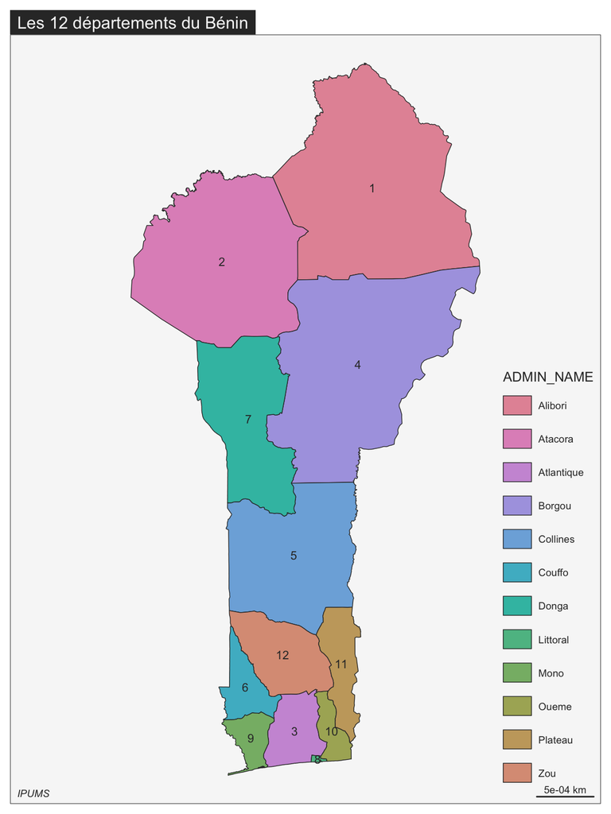

```r
mf_map(map, type="typo",var="ADMIN_NAME")
mf_label(map,var = "DEPT2013" )
mf_layout(title = "Les 12 départements du Bénin",credits = "IPUMS",arrow = F,frame =T)
```

## Modélisation du revenu total des ménages

On se propose d’expliquer la variable **hou_inc** qui mesure le revenu total des ménages en fonction du nombre de membres du ménage.

### Forme de la distribution

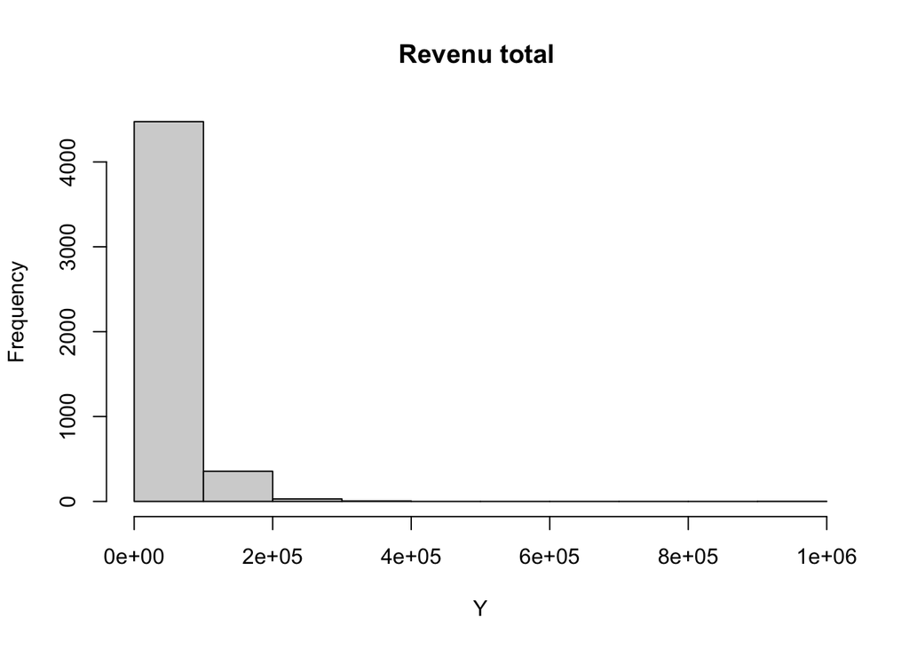

```r
Y<-sel$hou_inc
labelY<-"Revenu total "

hist(Y, main=labelY,breaks = 12)
```

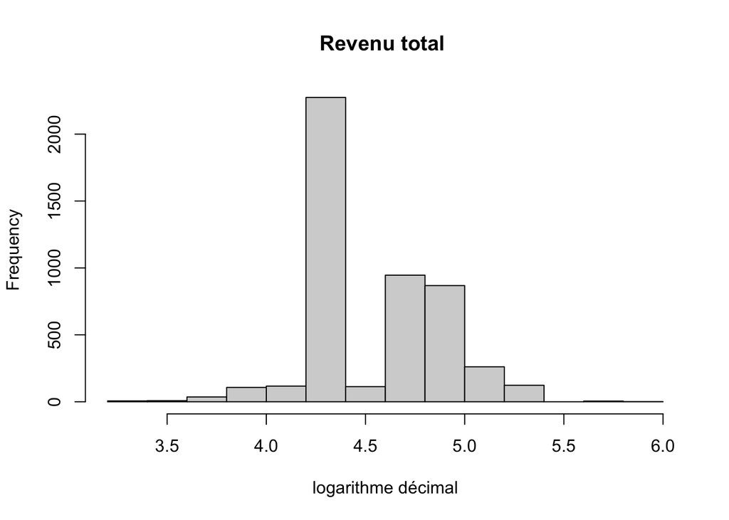

```r
hist(log10(Y), main=labelY, xlab = "logarithme décimal", breaks=12)
```

La distribution comporte une forte anomalie statistique liée au fait que nous avons attribué la valeur 20000 CFA à tous les ménages gagnant “*moins de 40000 CFA*”.

### Valeurs exceptionnelles

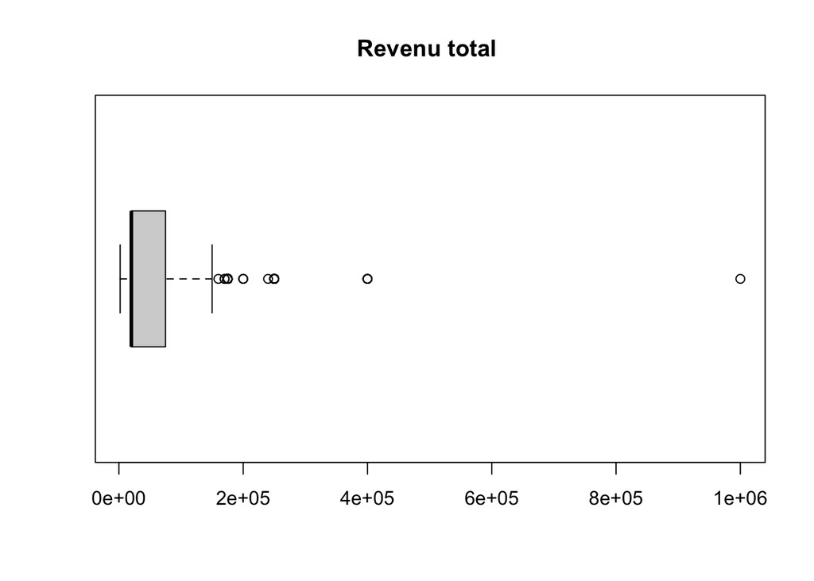

```r
boxplot(Y, main=labelY, horizontal=T)
```

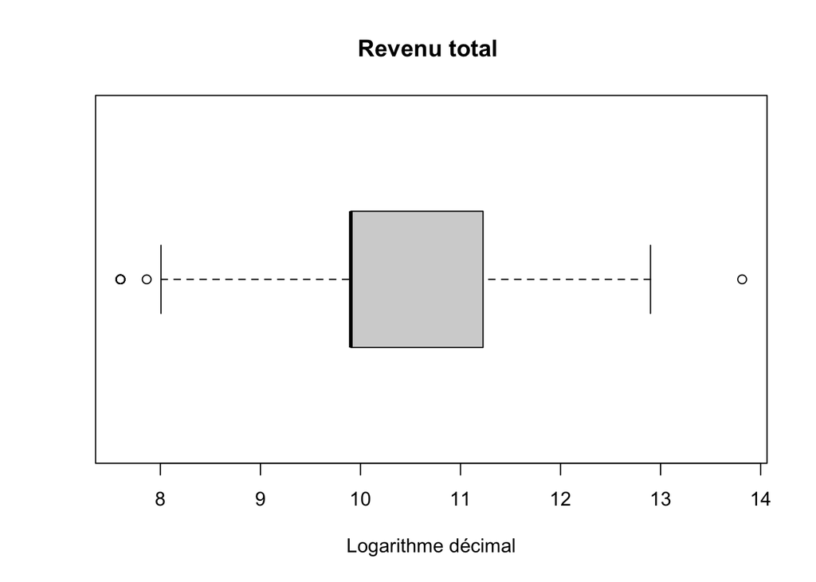

```r
boxplot(log(Y), main=labelY, horizontal=T, xlab = "Logarithme décimal")
```

La distribution comporte des valeurs exceptionnelles mais celles-ci disparaissent pour la plupart après transformation logarithmique.

### Normalité

```r
shapiro.test(Y)
```

```
    Shapiro-Wilk normality test

data:  Y
W = 0.65732, p-value < 2.2e-16
```

```r
shapiro.test(log(Y))
```

```
    Shapiro-Wilk normality test

data:  log(Y)
W = 0.88535, p-value < 2.2e-16
```

La distribution n’est pas gaussienne et elle ne le devient pas non plus après transformation logarithmique en raison de la cocnentration des valeurs autour de 20000. On décide de poursuivre l’analyse en utilisant désormais le log. du revenu.

### Modèle 1 : Ajustement linéaire

On commence par un modèle linéaire de type Y = aX+b

```r
Y<-sel$hou_inc
labelY <- "revenu total"
X2<-sel$hou_mbr
labelX2 <-"nombre de membres du ménage"

mod<-lm(Y~X2)
summary(mod)
```

```
Call:
lm(formula = Y ~ X2)

Residuals:
    Min      1Q  Median      3Q     Max
-114018  -21744   -8073   14585  731681

Coefficients:
            Estimate Std. Error t value Pr(>|t|)
(Intercept)  13422.2     1030.5   13.03   <2e-16 ***
X2            5664.4      156.8   36.11   <2e-16 ***
---
Signif. codes:  0 '***' 0.001 '**' 0.01 '*' 0.05 '.' 0.1 ' ' 1

Residual standard error: 37390 on 4863 degrees of freedom
Multiple R-squared:  0.2115,    Adjusted R-squared:  0.2113
F-statistic:  1304 on 1 and 4863 DF,  p-value: < 2.2e-16
```

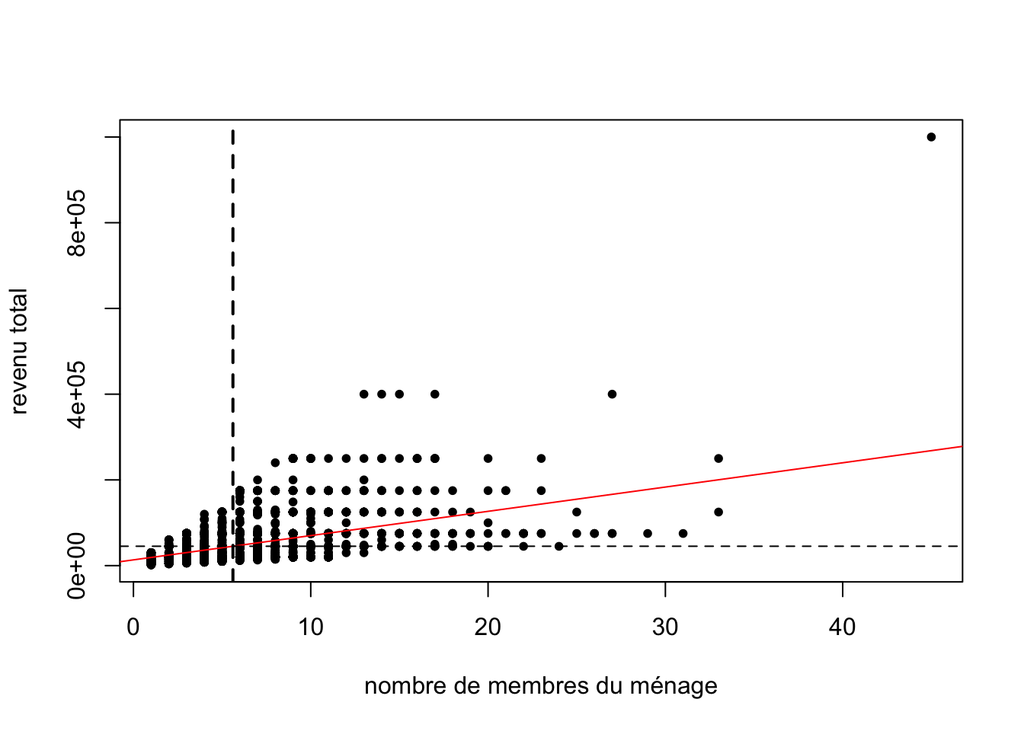

```r
plot(X2,Y, cex=1, col="black",pch=20, xlab=labelX2,ylab=labelY)
abline(mod,col="red")
abline(v=mean(X2),lty=2, lwd=2)
abline(h=mean(Y),lty=2)
```

### Modèle 1-bis : Ajustement linéaire sans outlier

```r
sel<-sel %>% filter(hou_inc < 500000)

Y<-sel$hou_inc
labelY <- "revenu total"
X2<-sel$hou_mbr
labelX2 <-"nombre de membres du ménage"

mod<-lm(Y~X2)
summary(mod)
```

```
Call:
lm(formula = Y ~ X2)

Residuals:
    Min      1Q  Median      3Q     Max
-100621  -21908   -7194   13377  316949

Coefficients:
            Estimate Std. Error t value Pr(>|t|)
(Intercept)  16194.4      997.1   16.24   <2e-16 ***
X2            5142.8      152.5   33.73   <2e-16 ***
---
Signif. codes:  0 '***' 0.001 '**' 0.01 '*' 0.05 '.' 0.1 ' ' 1

Residual standard error: 35840 on 4862 degrees of freedom
Multiple R-squared:  0.1896,    Adjusted R-squared:  0.1894
F-statistic:  1138 on 1 and 4862 DF,  p-value: < 2.2e-16
```

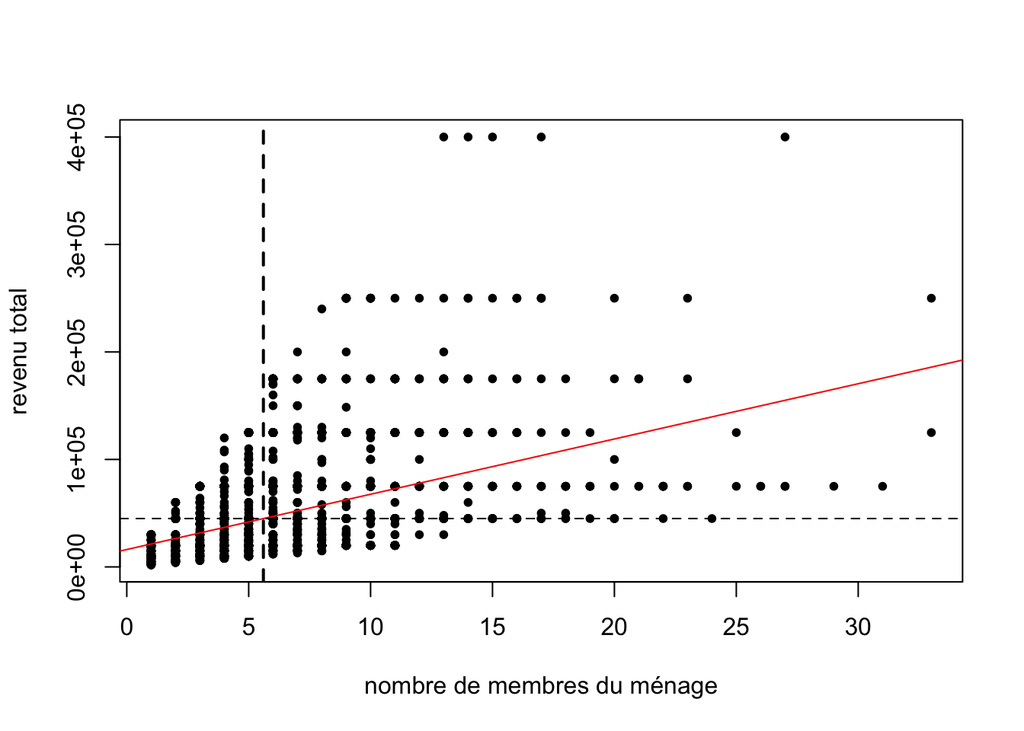

```r
plot(X2,Y, cex=1, col="black",pch=20, xlab=labelX2,ylab=labelY)
abline(mod,col="red")
abline(v=mean(X2),lty=2, lwd=2)
abline(h=mean(Y),lty=2)
```

La relation est un peu moins forte (r2 =19%) mais toujours très significative (p < 0.001). Toutefois elle est incorrecte sur le plan statistique car elle comporte visiblement une forte **hétéroscédasticité** (i.e. variance des résidus non homogène). Il faut donc procéder à des transformations logarithmiques sur X et/ou Y.

### Modèle 2 : Ajustement exponentiel

On passe à un modèle exponentiel de type log(Y) = aX+b

```r
Y<-log(sel$hou_inc)
labelY <- "revenu total (log)"
X2<-sel$hou_mbr
labelX2 <-"nombre de membres du ménage"

mod<-lm(Y~X2)
summary(mod)
```

```
Call:
lm(formula = Y ~ X2)

Residuals:
    Min      1Q  Median      3Q     Max
-2.3847 -0.4673 -0.1379  0.5362  1.7580

Coefficients:
            Estimate Std. Error t value Pr(>|t|)
(Intercept)  9.88931    0.01824  542.12   <2e-16 ***
X2           0.09630    0.00279   34.52   <2e-16 ***
---
Signif. codes:  0 '***' 0.001 '**' 0.01 '*' 0.05 '.' 0.1 ' ' 1

Residual standard error: 0.6558 on 4862 degrees of freedom
Multiple R-squared:  0.1969,    Adjusted R-squared:  0.1967
F-statistic:  1192 on 1 and 4862 DF,  p-value: < 2.2e-16
```

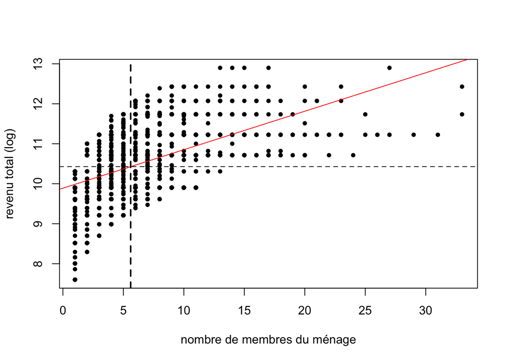

```r
plot(X2,Y, cex=1, col="black",pch=20, xlab=labelX2,ylab=labelY)
abline(mod,col="red")
abline(v=mean(X2),lty=2, lwd=2)
abline(h=mean(Y),lty=2)
```

Ce nouveau modèle demeure significatif (p<0.001), explique un peu plus de variance (r2 = 20%) et élimine l’effet de l’hétéroscédasticité. Mais on voit que le nuage de point affiche désormais une courbure ce qui crée une **autocorrélation des résidus** indiquant que le modèle n’est toujours pas correct d’un point de vue statistique.

### Modèle 3 : Ajustement puissance

On passe à un modèle exponentiel de type log(Y) = a.log(X)+b

```r
Y<-log(sel$hou_inc)
labelY <- "revenu total (log)"
X2<-log(sel$hou_mbr)
labelX2 <-"nombre de membres du ménage (log)"

mod<-lm(Y~X2)
summary(mod)
```

```
Call:
lm(formula = Y ~ X2)

Residuals:
     Min       1Q   Median       3Q      Max
-2.02346 -0.56251 -0.08335  0.51347  1.93356

Coefficients:
            Estimate Std. Error t value Pr(>|t|)
(Intercept)  9.62437    0.02391  402.48   <2e-16 ***
X2           0.52293    0.01432   36.52   <2e-16 ***
---
Signif. codes:  0 '***' 0.001 '**' 0.01 '*' 0.05 '.' 0.1 ' ' 1

Residual standard error: 0.6483 on 4862 degrees of freedom
Multiple R-squared:  0.2152,    Adjusted R-squared:  0.2151
F-statistic:  1333 on 1 and 4862 DF,  p-value: < 2.2e-16
```

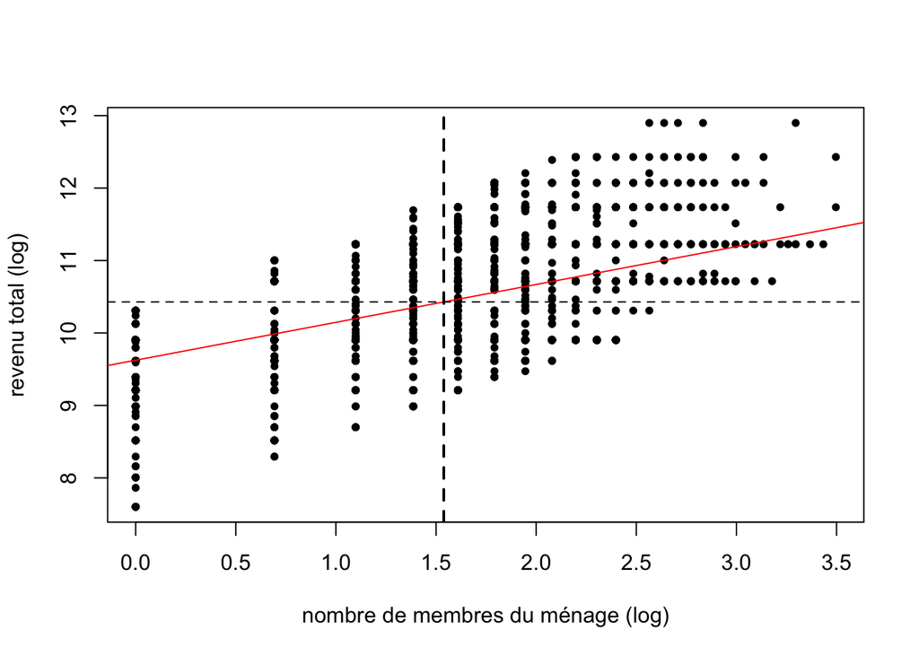

```r
plot(X2,Y, cex=1, col="black",pch=20, xlab=labelX2,ylab=labelY)
abline(mod,col="red")
abline(v=mean(X2),lty=2, lwd=2)
abline(h=mean(Y),lty=2)
```

```r
exp(9.624)
```

```
[1] 15123.42
```

Le pouvoir explicatif du modèle est toujours très significatif un peu plus élevé que précédemment (r2 = 21.5%) et la plupart des défauts statistiques ont été corrigés même s’ils demeurent des imperfections liées au fait qu’on a utilisé des centres de tranches de revenus comportant une certaine imprécision. L’équation du modèle s’écrit donc sous la forme

$log(Revenu) = 0.523.log(NBmembres) + 9.624$

Ce que l’on peut transformer en :

$Revenu = exp[0.523.log(NBmembres) + 9.624]$

d’où

$Revenu = exp(9.624) . (NBmembres)^{0.523}$

et finalement

$Revenu = 15123 . (NBmembres)^{0.523}$

Cette équation signifie que le revenu total est en théorie de 15123 CFA pour un ménage d’une personne et qu’il augmente ensuite de façon à peu près proportionnelle à la racine carrée du nombre de membres du ménage (en effet $X^{0.5} = \sqrt{X}$). On peut construire un tableau montrant le revenu attendu des ménages en fonction du nombre de personnes :

```r
nb<-c(1:20)
inc<-15123*nb**0.523
df<-data.frame(nb,inc)
kable(df,
      caption = "Revenu des ménages en fonction de leur taille",
      digits = 0,
      col.names = c("Taille du ménage","Revenu attendu")
      )
```

Revenu des ménages en fonction de leur taille

| Taille du ménage | Revenu attendu |
| --- | --- |
| 1 | 15123 |
| 2 | 21731 |
| 3 | 26864 |
| 4 | 31226 |
| 5 | 35091 |
| 6 | 38602 |
| 7 | 41843 |
| 8 | 44870 |
| 9 | 47721 |
| 10 | 50424 |
| 11 | 53001 |
| 12 | 55469 |
| 13 | 57840 |
| 14 | 60126 |
| 15 | 62335 |
| 16 | 64475 |
| 17 | 66552 |
| 18 | 68572 |
| 19 | 70538 |
| 20 | 72456 |

Ou bien sous forme graphique :

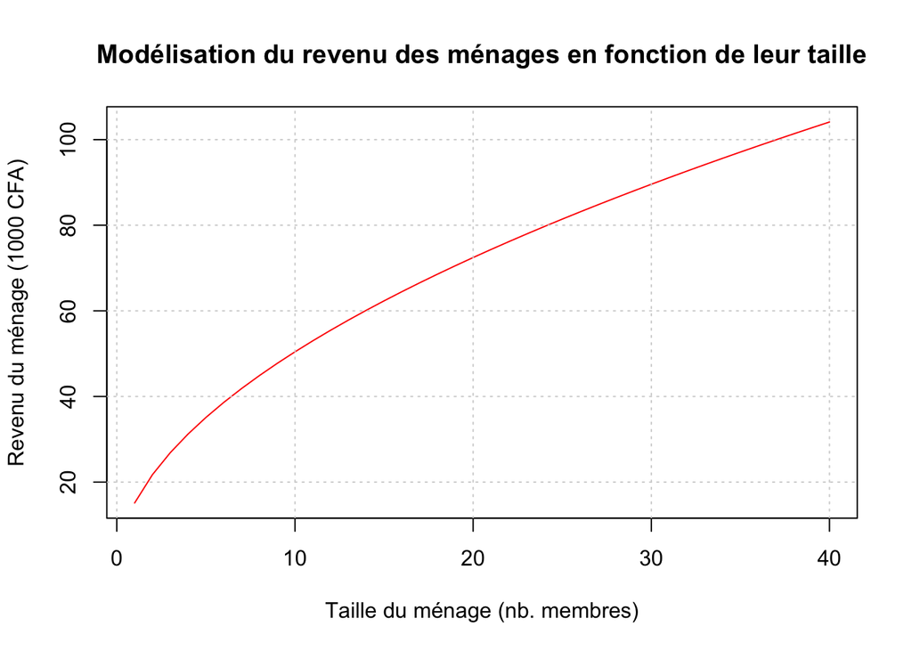

```r
nb<-c(1:40)
inc<-15123*nb**0.523 / 1000
plot(nb,inc,
     type="l",
     xlab = "Taille du ménage (nb. membres)",
     ylab = "Revenu du ménage (1000 CFA)",
     main = "Modélisation du revenu des ménages en fonction de leur taille",
     col="red")
grid()
```

### Discussion

Compte-tenu du caractère non-linéaire de la relation entre revenu et taille du ménage, il serait peu judicieux de calculer un indicateur tel que le revenu moyen par personne. Il semble plus judicieux de prendre comme indicateur de richesse relative du ménage le rapport entre la valeur observée et la valeur théorique selon le modèle défini ci-dessus.

```r
sel$hou_rich <- sel$hou_inc/(15123*(sel$hou_mbr**0.523))
```

## C. Analyse des déterminants de la richesse relative du ménage

On se propose d’expliquer la variable **hou_rich** qui a été créée à l’étape précédente et qui mesure sa richesse relative, toutes choses égales quant à sa taille.

### Forme de la distribution

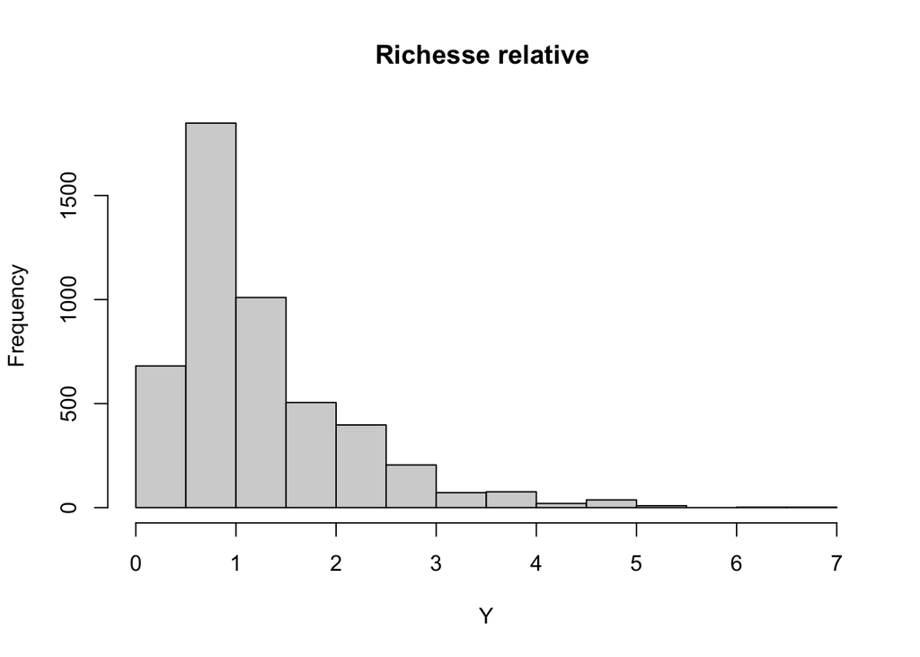

```r
Y<-sel$hou_rich
labelY<-"Richesse relative "

hist(Y, main=labelY,breaks = 12)
```

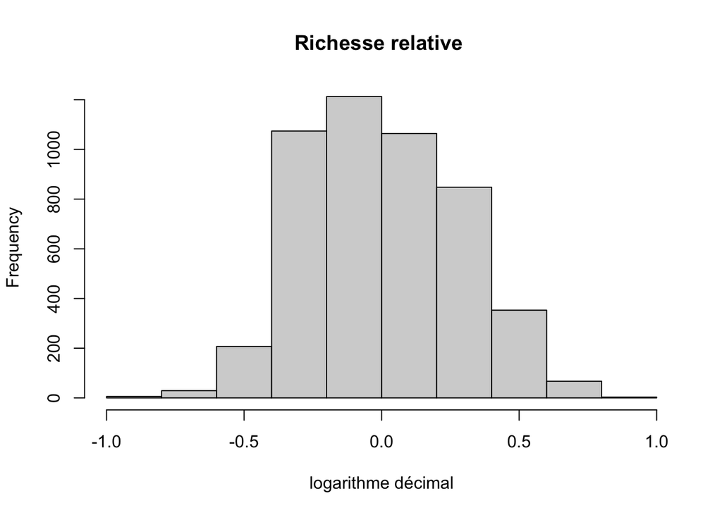

```r
hist(log10(Y), main=labelY, xlab = "logarithme décimal", breaks=12)
```

La distribution est unimodale mais asymétrique à gauche. Après transformation logarithmique elle apparaît plus symétrique.

### Valeurs exceptionnelles

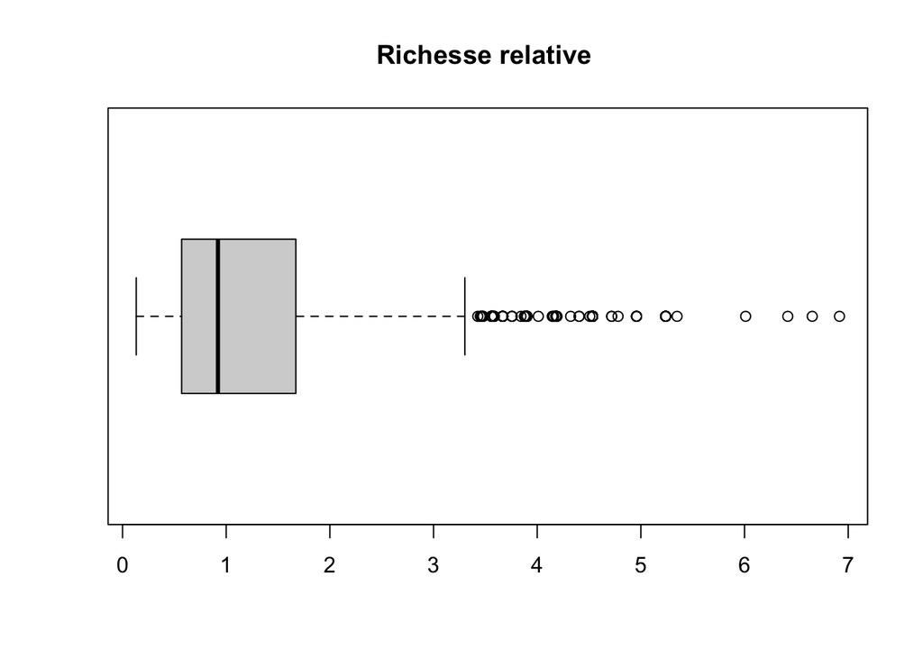

```r
boxplot(Y, main=labelY, horizontal=T)
```

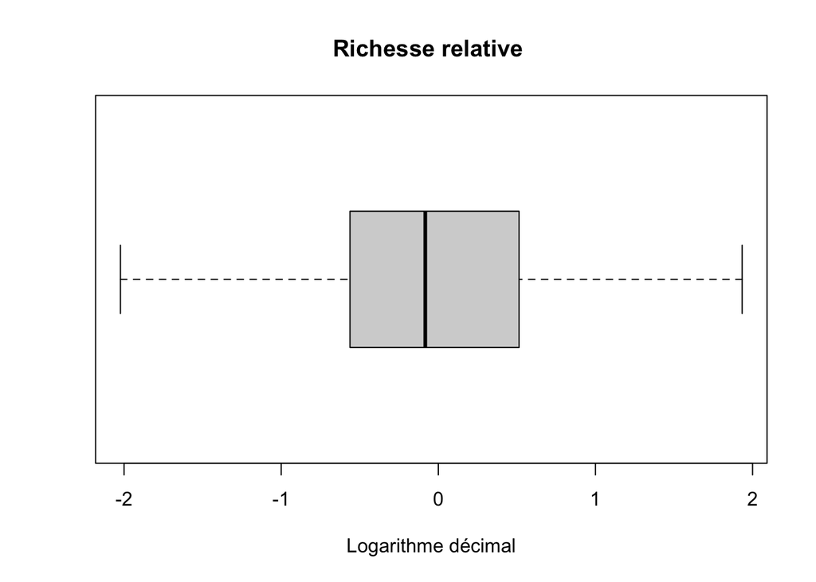

```r
boxplot(log(Y), main=labelY, horizontal=T, xlab = "Logarithme décimal")
```

La distribution comporte des valeurs exceptionnelles mais celles-ci disparaissent pratiquement après transformation logarithmique.

### Normalité

```r
shapiro.test(Y)
```

```
    Shapiro-Wilk normality test

data:  Y
W = 0.84285, p-value < 2.2e-16
```

```r
shapiro.test(log(Y))
```

```
    Shapiro-Wilk normality test

data:  log(Y)
W = 0.97933, p-value < 2.2e-16
```

- **Commentaire** : La distribution n’est pas gaussienne et elle ne le devient pas non plus après transformation logarithmique en raison de la cocnentration des valeurs autour de 20000 (Cf. introduction). On décide de poursuivre l’analyse en utilisant désormais le log. du revenu

```r
Y<-log(sel$hou_rich)
labelY<-"Richesse relative (log)"
```

On va tester l’effet de variables indépendantes qualitatives

### Modèle 1 : Les ménages urbains sont-ils plus riches ?

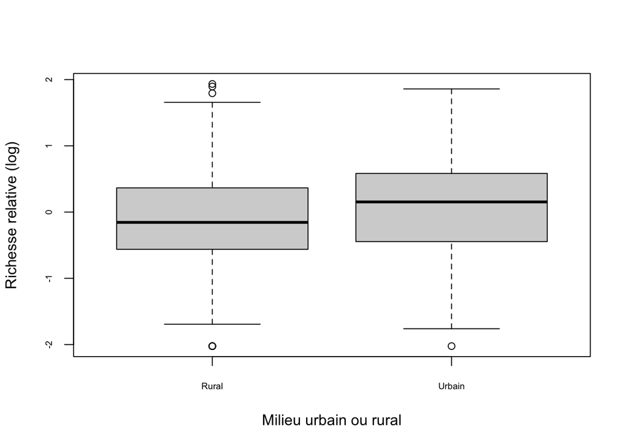

```r
Q1<-as.factor(sel$loc_urb)
levels(Q1)<-c("Rural","Urbain")
labelQ1 = "Milieu urbain ou rural"

plot(Y~Q1,cex.axis=0.6, xlab=labelQ1, ylab=labelY)
```

```r
mod<-lm(Y~Q1)
summary(mod)
```

```
Call:
lm(formula = Y ~ Q1)

Residuals:
    Min      1Q  Median      3Q     Max
-2.1191 -0.5415 -0.0233  0.4751  2.0118

Coefficients:
            Estimate Std. Error t value Pr(>|t|)
(Intercept) -0.07806    0.01242  -6.284 3.58e-10 ***
Q1Urbain     0.17410    0.01852   9.403  < 2e-16 ***
---
Signif. codes:  0 '***' 0.001 '**' 0.01 '*' 0.05 '.' 0.1 ' ' 1

Residual standard error: 0.6424 on 4862 degrees of freedom
Multiple R-squared:  0.01786,   Adjusted R-squared:  0.01766
F-statistic: 88.41 on 1 and 4862 DF,  p-value: < 2.2e-16
```

```r
anova(mod)
```

```
Analysis of Variance Table

Response: Y
            Df  Sum Sq Mean Sq F value    Pr(>F)
Q1           1   36.49  36.489  88.407 < 2.2e-16 ***
Residuals 4862 2006.72   0.413
---
Signif. codes:  0 '***' 0.001 '**' 0.01 '*' 0.05 '.' 0.1 ' ' 1
```

- **Commentaire** : les ménages urbains sont légèrement plus riches que les ménages ruraux. La relation est significative mais son pouvoir explicatif est faible. La différence relative est égale à 0.174 en log soit un rapport de $exp(0.174) = 1.19$ qui implique une richesse supérieure d’environ 19% pour les ménages urbains.

### Modèle 2 : Les ménages dont le chef est un homme sont-ils plus riches ?

```r
Q2<-as.factor(sel$hea_sex)
levels(Q2)
```

```
[1] "Female" "Male"
```

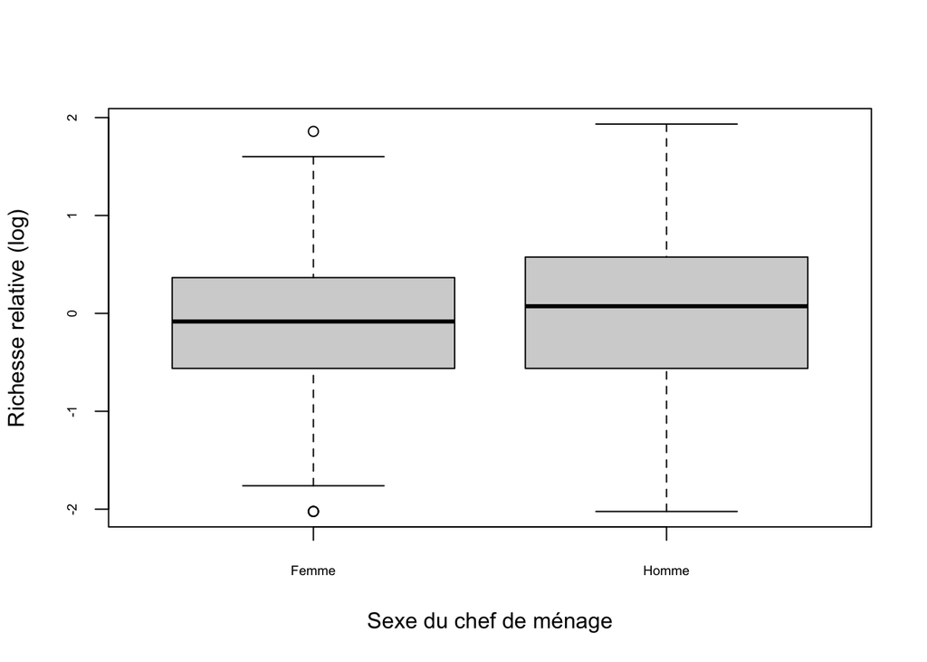

```r
levels(Q2)<-c("Femme","Homme")
labelQ2 = "Sexe du chef de ménage"

plot(Y~Q2,cex.axis=0.6, xlab=labelQ2, ylab=labelY)
```

```r
mod<-lm(Y~Q2)
summary(mod)
```

```
Call:
lm(formula = Y ~ Q2)

Residuals:
     Min       1Q   Median       3Q      Max
-2.07604 -0.49849 -0.00969  0.46290  1.93225

Coefficients:
            Estimate Std. Error t value Pr(>|t|)
(Intercept) -0.07331    0.01432  -5.118 3.21e-07 ***
Q2Homme      0.12629    0.01876   6.730 1.89e-11 ***
---
Signif. codes:  0 '***' 0.001 '**' 0.01 '*' 0.05 '.' 0.1 ' ' 1

Residual standard error: 0.6453 on 4862 degrees of freedom
Multiple R-squared:  0.009231,  Adjusted R-squared:  0.009027
F-statistic:  45.3 on 1 and 4862 DF,  p-value: 1.888e-11
```

```r
anova(mod)
```

```
Analysis of Variance Table

Response: Y
            Df  Sum Sq Mean Sq F value    Pr(>F)
Q2           1   18.86 18.8602  45.298 1.888e-11 ***
Residuals 4862 2024.35  0.4164
---
Signif. codes:  0 '***' 0.001 '**' 0.01 '*' 0.05 '.' 0.1 ' ' 1
```

- **Commentaire** : les ménages dont le chef est un homme sont légèrement plus riches que les ménages dont le chef est une femme . La relation est significative mais son pouvoir explicatif est faible. La différence relative est égale à 0.126 en log soit un rapport de $exp(0.126) = 1.13$ qui implique une richesse supérieure d’environ 13% pour les ménages dont le chef est un homme.

### Modèle 3 : La richesse des ménages varie-t-elle selon les départements

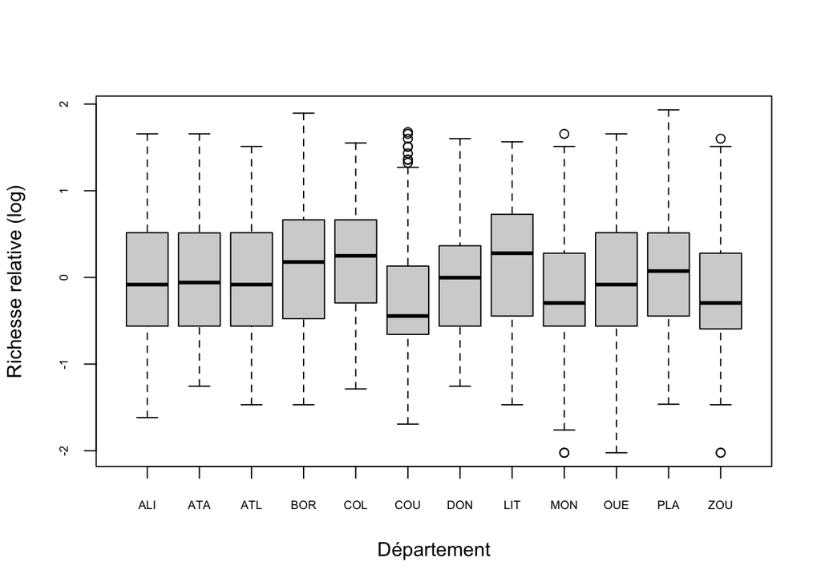

```r
Q3<-as.factor(substr(sel$loc_dep,1,3))
labelQ3 <- "Département"

plot(Y~Q3,cex.axis=0.6, xlab=labelQ3, ylab=labelY)
```

```r
mod<-lm(Y~Q3)
summary(mod)
```

```
Call:
lm(formula = Y ~ Q3)

Residuals:
     Min       1Q   Median       3Q      Max
-2.02674 -0.50092 -0.04339  0.46192  1.94100

Coefficients:
             Estimate Std. Error t value Pr(>|t|)
(Intercept) -0.009793   0.034441  -0.284  0.77617
Q3ATA       -0.006997   0.046921  -0.149  0.88147
Q3ATL       -0.005519   0.049791  -0.111  0.91175
Q3BOR        0.151092   0.046324   3.262  0.00112 **
Q3COL        0.176282   0.044632   3.950 7.94e-05 ***
Q3COU       -0.254332   0.045433  -5.598 2.29e-08 ***
Q3DON        0.016994   0.047645   0.357  0.72135
Q3LIT        0.208135   0.046921   4.436 9.38e-06 ***
Q3MON       -0.146867   0.045895  -3.200  0.00138 **
Q3OUE        0.013460   0.045086   0.299  0.76531
Q3PLA        0.087189   0.045872   1.901  0.05740 .
Q3ZOU       -0.155016   0.049229  -3.149  0.00165 **
---
Signif. codes:  0 '***' 0.001 '**' 0.01 '*' 0.05 '.' 0.1 ' ' 1

Residual standard error: 0.6341 on 4852 degrees of freedom
Multiple R-squared:  0.0451,    Adjusted R-squared:  0.04293
F-statistic: 20.83 on 11 and 4852 DF,  p-value: < 2.2e-16
```

```r
anova(mod)
```

```
Analysis of Variance Table

Response: Y
            Df  Sum Sq Mean Sq F value    Pr(>F)
Q3          11   92.15  8.3768  20.832 < 2.2e-16 ***
Residuals 4852 1951.06  0.4021
---
Signif. codes:  0 '***' 0.001 '**' 0.01 '*' 0.05 '.' 0.1 ' ' 1
```